# Hand-On Quiz PCA Learners notebook

## Context:

In this case study, we will use the Air pollution dataset which contains information about 13 months of data on major pollutants and meteorological levels of a city.

## Objective:

The objective of this problem is to reduce the number of features by using dimensionality reduction techniques like PCA and extract insights.

## Importing libraries and overview of the dataset

```python
import pandas as pd
import numpy as np
import matplotlib.pyplot as plt
import seaborn as sns

#to scale the data using z-score
from sklearn.preprocessing import StandardScaler

#Importing PCA and TSNE
from sklearn.decomposition import PCA

import warnings
warnings.filterwarnings('ignore')
```

#### Loading data

```python
#Loading data
data= pd.read_csv("Air_Pollution.csv")
```

```python
data.head()
```

|  | SrNo | Date | NO | CO | NO2 | O3 | SO2 | PM2.5 | Benzene | Toulene | ... | WindSpeed | VerticalWindSpeed | Solar | BarPressure | Weather | PD_PM2.5 | PD_PM10 | PD_NO2 | PD_SO2 | PD_CO |
| --- | --- | --- | --- | --- | --- | --- | --- | --- | --- | --- | --- | --- | --- | --- | --- | --- | --- | --- | --- | --- | --- |
| 0 | 1 | 04-04-2015 | 7.22 | 1.77 | 47.94 | 51.07 | 16.88 | 48.99 | 2.53 | 9.65 | ... | 1.22 | 0.08 | 162.18 | 732.25 | Summer | NaN | NaN | NaN | NaN | NaN |
| 1 | 2 | 05-04-2015 | 6.99 | 0.22 | 45.27 | 19.26 | 16.71 | 60.20 | 3.19 | 11.10 | ... | 0.62 | -0.04 | 99.37 | 734.05 | Summer | 48.99 | 82.85 | 47.94 | 16.88 | 1.77 |
| 2 | 3 | 09-04-2015 | 7.60 | 0.50 | 59.86 | 94.29 | 13.11 | 46.93 | 2.29 | 8.61 | ... | 1.55 | -0.17 | 146.94 | 728.08 | Summer | NaN | NaN | NaN | NaN | NaN |
| 3 | 4 | 10-04-2015 | 7.57 | 0.77 | 63.56 | 66.91 | 16.19 | 112.95 | 3.92 | 10.76 | ... | 1.18 | -0.15 | 150.07 | 730.47 | Summer | 46.93 | 171.36 | 59.86 | 13.11 | 0.50 |
| 4 | 5 | 11-04-2015 | 8.34 | 0.48 | 61.99 | 69.48 | 20.28 | 104.87 | 5.19 | 15.95 | ... | 0.88 | 0.15 | 137.01 | 730.62 | Summer | 112.95 | 232.22 | 63.56 | 16.19 | 0.77 |

5 rows × 27 columns

#### Check the info of the data

```python
data.shape
```

```
(403, 27)
```

```python
data.info()
```

```
<class 'pandas.core.frame.DataFrame'>
RangeIndex: 403 entries, 0 to 402
Data columns (total 27 columns):
 #   Column             Non-Null Count  Dtype
---  ------             --------------  -----
 0   SrNo               403 non-null    int64
 1   Date               403 non-null    object
 2   NO                 401 non-null    float64
 3   CO                 402 non-null    float64
 4   NO2                401 non-null    float64
 5   O3                 397 non-null    float64
 6   SO2                399 non-null    float64
 7   PM2.5              401 non-null    float64
 8   Benzene            402 non-null    float64
 9   Toulene            402 non-null    float64
```

[output cut: 19 more lines]

- There are 403 observations and 27 columns in the data.
- All the columns except Date and Weather are of numeric data type.
- The Date and SrNo for all observations would be unique. We can drop these columns as they would not add value to our analysis.
- Weather is of object data type. We can create dummy variables for each category and convert it to numeric data type.
- The majority of the columns have some missing values.
- Let's check the number of missing values in each column.

```python
data.isnull().sum()
```

```
SrNo                  0
Date                  0
NO                    2
CO                    1
NO2                   2
O3                    6
SO2                   4
PM2.5                 2
Benzene               1
Toulene               1
P_Xylene             31
NOx                   2
PM10                  2
WindDirection         1
NH3                   2
RH                    1
Temp                  2
WindSpeed             1
VerticalWindSpeed     2
Solar                 2
BarPressure           2
Weather               0
PD_PM2.5             10
PD_PM10              11
PD_NO2               12
PD_SO2               13
PD_CO                11
dtype: int64
```

#### Data Preprocessing

```python
data.drop(columns=["SrNo", "Date"], inplace=True)
```

#### fillna "Weather" (Object) column by mode() and other numerical columns by median()

```python
#Imputing missing values with mode(most frequent) for the Weather column and with median for all other columns
for col in data.columns:
    if col == "Weather":
        data[col].fillna(value=data[col].mode()[0], inplace=True)
    else:
        data[col].fillna(value=data[col].median(), inplace=True)
```

```python
#Creating dummy variables for Weather column
data = pd.get_dummies(data, drop_first=True)
```

```python
data.head(3)
```

|  | NO | CO | NO2 | O3 | SO2 | PM2.5 | Benzene | Toulene | P_Xylene | NOx | ... | BarPressure | PD_PM2.5 | PD_PM10 | PD_NO2 | PD_SO2 | PD_CO | Weather_Monsoon | Weather_Spring | Weather_Summer | Weather_Winter |
| --- | --- | --- | --- | --- | --- | --- | --- | --- | --- | --- | --- | --- | --- | --- | --- | --- | --- | --- | --- | --- | --- |
| 0 | 7.22 | 1.77 | 47.94 | 51.07 | 16.88 | 48.99 | 2.53 | 9.65 | 3.00 | 52.97 | ... | 732.25 | 108.24 | 250.105 | 73.52 | 21.605 | 1.775 | False | False | True | False |
| 1 | 6.99 | 0.22 | 45.27 | 19.26 | 16.71 | 60.20 | 3.19 | 11.10 | 2.67 | 51.31 | ... | 734.05 | 48.99 | 82.850 | 47.94 | 16.880 | 1.770 | False | False | True | False |
| 2 | 7.60 | 0.50 | 59.86 | 94.29 | 13.11 | 46.93 | 2.29 | 8.61 | 3.43 | 65.53 | ... | 728.08 | 108.24 | 250.105 | 73.52 | 21.605 | 1.775 | False | False | True | False |

3 rows × 28 columns

```python
data.isnull().sum()
```

```
NO                   0
CO                   0
NO2                  0
O3                   0
SO2                  0
PM2.5                0
Benzene              0
Toulene              0
P_Xylene             0
NOx                  0
PM10                 0
WindDirection        0
NH3                  0
RH                   0
Temp                 0
WindSpeed            0
VerticalWindSpeed    0
Solar                0
BarPressure          0
PD_PM2.5             0
PD_PM10              0
PD_NO2               0
PD_SO2               0
PD_CO                0
Weather_Monsoon      0
Weather_Spring       0
Weather_Summer       0
Weather_Winter       0
dtype: int64
```

### Question 1: Define Standard scaler and fit to the data_scaled

```python
scaler = StandardScaler() ## sclar = __________
data_scaled = scaler.fit_transform(data) ## data_scales = _________________
```

```python
data_scaled
```

```
array([[-0.76268524, -0.27471889, -1.0281037 , ..., -0.41001944,
         1.37060987, -0.39754997],
       [-0.76505914, -1.24483113, -1.13172891, ..., -0.41001944,
         1.37060987, -0.39754997],
       [-0.75876315, -1.06958505, -0.56547731, ..., -0.41001944,
         1.37060987, -0.39754997],
       ...,
       [-0.82027806, -0.9882208 , -1.62074674, ..., -0.41001944,
         1.37060987, -0.39754997],
       [-0.48235889, -0.58765832, -0.50920145, ..., -0.41001944,
         1.37060987, -0.39754997],
       [-0.5988863 , -0.70657531, -0.65513058, ..., -0.41001944,
         1.37060987, -0.39754997]])
```

```python
data_scaled = pd.DataFrame(data_scaled, columns=data.columns)
```

```python
data_scaled.head()
```

|  | NO | CO | NO2 | O3 | SO2 | PM2.5 | Benzene | Toulene | P_Xylene | NOx | ... | BarPressure | PD_PM2.5 | PD_PM10 | PD_NO2 | PD_SO2 | PD_CO | Weather_Monsoon | Weather_Spring | Weather_Summer | Weather_Winter |
| --- | --- | --- | --- | --- | --- | --- | --- | --- | --- | --- | --- | --- | --- | --- | --- | --- | --- | --- | --- | --- | --- |
| 0 | -0.762685 | -0.274719 | -1.028104 | -0.176087 | -0.360903 | -0.966206 | -1.005290 | -0.726103 | -0.766391 | -1.006218 | ... | -0.175488 | -0.259436 | -0.113049 | -0.030312 | -0.168884 | -0.262123 | -0.426401 | -0.410019 | 1.37061 | -0.39755 |
| 1 | -0.765059 | -1.244831 | -1.131729 | -1.256817 | -0.367671 | -0.832590 | -0.839185 | -0.586470 | -0.817281 | -1.018023 | ... | 0.828051 | -0.967381 | -1.365729 | -1.030531 | -0.358008 | -0.265288 | -0.426401 | -0.410019 | 1.37061 | -0.39755 |
| 2 | -0.758763 | -1.069585 | -0.565477 | 1.292291 | -0.510985 | -0.990760 | -1.065691 | -0.826253 | -0.700079 | -0.916904 | ... | -2.500352 | -0.259436 | -0.113049 | -0.030312 | -0.168884 | -0.262123 | -0.426401 | -0.410019 | 1.37061 | -0.39755 |
| 3 | -0.759073 | -0.900598 | -0.421877 | 0.362069 | -0.388372 | -0.203844 | -0.655463 | -0.619211 | -0.510398 | -0.893437 | ... | -1.167876 | -0.991995 | -0.702821 | -0.564440 | -0.508908 | -1.069106 | -0.426401 | -0.410019 | 1.37061 | -0.39755 |
| 4 | -0.751125 | -1.082103 | -0.482810 | 0.449383 | -0.225551 | -0.300152 | -0.335838 | -0.119422 | -0.047760 | -0.903606 | ... | -1.084248 | -0.203159 | -0.247001 | -0.419764 | -0.385627 | -0.898215 | -0.426401 | -0.410019 | 1.37061 | -0.39755 |

5 rows × 28 columns

```python
data_scaled["NO"].mean(), data_scaled["NO"].std()
```

```
(0.0, 1.0012430085593884)
```

## Principal Component Analysis

### Question 2: Define PCA with n components and random_state =1 and fit to the scaled data.

```python
#Defining the number of principal components to generate
n = data_scaled.shape[1]

#Finding principal components for the data
# pca1 = PCA(__________)
pca1= PCA(n_components = n)

### data_pca = pd.DataFrame(pca1._________________)
data_pca = pd.DataFrame(pca1.fit_transform(data_scaled))
### Note: data_pca are the projected values of


#The percentage of variance explained by each principal component
exp_var1 = pca1.explained_variance_ratio_
```

#### The components_ attribute of the PCA object contains the principal components' loadings.

#### The loadings tells us how much each feature contributes to each principal component.

```python
## the Unit Vectors (with value and direction), the shifted axes coordinates
pca_components = pca1.components_
```

```python
len(exp_var1), exp_var1[:3]
```

```
(28, array([0.40157886, 0.12764382, 0.07673692]))
```

```python
pca_components[:2]
```

```
array([[ 0.25213415,  0.20996286,  0.19352442,  0.02087459,  0.12162144,
         0.26058925,  0.26967353,  0.24682367,  0.24945171,  0.24256298,
         0.23314305,  0.08952004,  0.24495336,  0.09587962, -0.21197595,
        -0.1979321 , -0.03202914, -0.18417139,  0.13258267,  0.24453444,
         0.2166033 ,  0.17710641,  0.13265519,  0.18659745, -0.10257151,
         0.02391551, -0.13342026,  0.17163936],
       [-0.05294367,  0.03861754, -0.21751536, -0.37991183, -0.18727886,
        -0.0603237 ,  0.08726319,  0.0968195 ,  0.07017578,  0.01342467,
        -0.17228211, -0.06459896,  0.03914644,  0.46418941, -0.17458743,
        -0.0375521 , -0.21770878, -0.216867  , -0.00707544, -0.05256927,
        -0.1529977 , -0.2254726 , -0.17263075,  0.04852715,  0.3628641 ,
        -0.04463042, -0.32844228,  0.12378741]])
```

#### Test Unit vectors (The shifted axes): pca_components[0] and pca_components[1] are the vectors (values and directions) that are orthogonal to one another.

#### So the dot product of these two vectors are zero

```python
#### pca_components[0] and pca_components[1] are the vectors that are orthogonal to one another.

#### So the dot product of these two vectors are zero

round(np.dot(pca_components[1],  pca_components[0]),4)
```

```
0.0
```

```python
data_pca.shape
```

```
(403, 28)
```

```python
### Theses are projected points (distance from the Origin) along the components.

data_pca.head()
```

|  | 0 | 1 | 2 | 3 | 4 | 5 | 6 | 7 | 8 | 9 | ... | 18 | 19 | 20 | 21 | 22 | 23 | 24 | 25 | 26 | 27 |
| --- | --- | --- | --- | --- | --- | --- | --- | --- | --- | --- | --- | --- | --- | --- | --- | --- | --- | --- | --- | --- | --- |
| 0 | -2.742064 | 0.090409 | -0.544034 | -0.639932 | 1.305489 | 1.049067 | -0.965436 | 0.103459 | 0.051540 | 0.198931 | ... | 0.675502 | 0.804767 | -0.665327 | 0.583680 | -0.496965 | 0.237807 | -0.311625 | 0.022113 | -0.256680 | -0.016397 |
| 1 | -2.518826 | 1.834496 | -0.820265 | -0.125443 | 1.226361 | 0.136618 | -0.763263 | -1.243801 | -0.533671 | 0.864223 | ... | 0.488313 | 1.215222 | -0.411048 | 0.421006 | -0.146722 | 0.095045 | -0.074077 | -0.198902 | -0.279627 | -0.056044 |
| 2 | -3.234021 | -1.678367 | 0.109291 | -0.832131 | -0.425673 | -0.604315 | 0.621228 | 0.278716 | 1.541888 | 0.131122 | ... | 0.802738 | 0.111171 | 0.242053 | 0.430897 | -0.351020 | 0.200112 | -0.122626 | -0.160006 | -0.106472 | 0.030652 |
| 3 | -2.722372 | -0.876209 | 0.114949 | -0.334952 | -0.926435 | -1.151151 | 0.121267 | -0.785277 | 0.602173 | -0.051567 | ... | 0.372883 | 0.380353 | 0.109244 | 0.607604 | -0.328072 | 0.150243 | -0.260876 | 0.126214 | -0.057704 | 0.025010 |
| 4 | -1.952577 | -1.032156 | 0.308900 | -0.634766 | -0.561540 | -0.982848 | 0.067600 | -0.769568 | 0.042768 | 0.356044 | ... | 0.623313 | -0.002952 | 0.282050 | 0.437699 | -0.152451 | 0.206255 | -0.137898 | -0.130241 | -0.113247 | 0.011455 |

5 rows × 28 columns

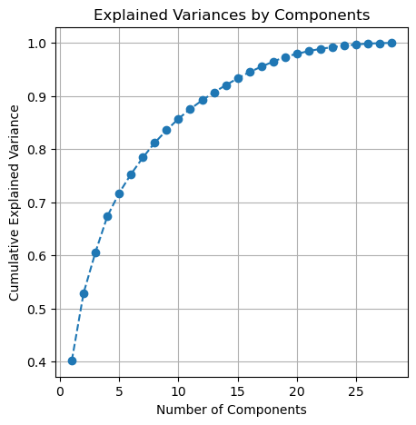

```python
# visulaize the explained variance by individual components
plt.figure(figsize = (5,5))
plt.plot(range(1,29), pca1.explained_variance_ratio_.cumsum(), marker = 'o', linestyle = '--')
plt.title("Explained Variances by Components")
plt.xlabel("Number of Components")
plt.ylabel("Cumulative Explained Variance")
plt.grid()
plt.show()
```

### Question 3: How many Principal components explains more than 70% variance in the dataset

```python
# find the least number of components that can explain more than 70% variance
sum = 0
for ix, i in enumerate(exp_var1):
  sum = sum + i
  if(sum>0.7):
    print("Number of PCs that explain at least 70% variance: ", ix+1)
    break
```

```
Number of PCs that explain at least 70% variance:  5
```

```python
#Making a new dataframe with first 8 principal components and original features as indices
cols = ['PC1', 'PC2', 'PC3', 'PC4', 'PC5']

# cols = ['PC1', 'PC2']

pc1 = pd.DataFrame(np.round(pca1.components_.T[:, 0:5],2), index=data_scaled.columns, columns=cols)

# pc1 = pd.DataFrame(np.round(pca1.components_.T[:, 0:2],2), index=data_scaled.columns, columns=cols)
```

```python
pca1.components_[:2]
```

```
array([[ 0.25213415,  0.20996286,  0.19352442,  0.02087459,  0.12162144,
         0.26058925,  0.26967353,  0.24682367,  0.24945171,  0.24256298,
         0.23314305,  0.08952004,  0.24495336,  0.09587962, -0.21197595,
        -0.1979321 , -0.03202914, -0.18417139,  0.13258267,  0.24453444,
         0.2166033 ,  0.17710641,  0.13265519,  0.18659745, -0.10257151,
         0.02391551, -0.13342026,  0.17163936],
       [-0.05294367,  0.03861754, -0.21751536, -0.37991183, -0.18727886,
        -0.0603237 ,  0.08726319,  0.0968195 ,  0.07017578,  0.01342467,
        -0.17228211, -0.06459896,  0.03914644,  0.46418941, -0.17458743,
        -0.0375521 , -0.21770878, -0.216867  , -0.00707544, -0.05256927,
        -0.1529977 , -0.2254726 , -0.17263075,  0.04852715,  0.3628641 ,
        -0.04463042, -0.32844228,  0.12378741]])
```

##### Each PCA component vector or loading is an Unit Vector. So if we square the any PCA component and sum up, the sum should be 1

```python
# Each PCA component/vector is an Unit Vector. So we square the any PCA component and sum up, the sum should be 1
## Try with any component
comp_vec1 = pca1.components_[1]
print(type(comp_vec1))
print(np.sum(np.power(comp_vec1,2)))
```

```
<class 'numpy.ndarray'>
1.0000000000000016
```

### Question 4 : Interpret the coefficients of Five principal components from the below dataframe.

```python
def color_high(val):
    if val <= -0.25: # you can decide any value as per your understanding
        return 'background: pink'
    elif val >= 0.25:
        return 'background: skyblue'

pc1.style.applymap(color_high)
```

|  | PC1 | PC2 | PC3 | PC4 | PC5 |
| --- | --- | --- | --- | --- | --- |
| NO | 0.250000 | -0.050000 | 0.180000 | 0.140000 | -0.130000 |
| CO | 0.210000 | 0.040000 | 0.180000 | -0.000000 | -0.030000 |
| NO2 | 0.190000 | -0.220000 | 0.180000 | 0.060000 | 0.240000 |
| O3 | 0.020000 | -0.380000 | -0.020000 | 0.180000 | 0.080000 |
| SO2 | 0.120000 | -0.190000 | -0.200000 | 0.280000 | -0.110000 |
| PM2.5 | 0.260000 | -0.060000 | -0.100000 | -0.180000 | -0.140000 |
| Benzene | 0.270000 | 0.090000 | 0.150000 | 0.010000 | -0.010000 |
| Toulene | 0.250000 | 0.100000 | 0.270000 | 0.080000 | 0.010000 |
| P_Xylene | 0.250000 | 0.070000 | 0.220000 | 0.030000 | -0.100000 |
| NOx | 0.240000 | 0.010000 | 0.260000 | 0.150000 | -0.120000 |
| PM10 | 0.230000 | -0.170000 | -0.100000 | -0.160000 | -0.200000 |
| WindDirection | 0.090000 | -0.060000 | 0.030000 | 0.130000 | -0.560000 |
| NH3 | 0.240000 | 0.040000 | -0.120000 | -0.080000 | 0.110000 |
| RH | 0.100000 | 0.460000 | -0.020000 | 0.010000 | 0.180000 |
| Temp | -0.210000 | -0.170000 | 0.300000 | -0.060000 | -0.200000 |
| WindSpeed | -0.200000 | -0.040000 | -0.270000 | -0.070000 | -0.070000 |
| VerticalWindSpeed | -0.030000 | -0.220000 | 0.280000 | -0.200000 | 0.310000 |
| Solar | -0.180000 | -0.220000 | 0.140000 | 0.110000 | -0.270000 |
| BarPressure | 0.130000 | -0.010000 | -0.290000 | 0.270000 | -0.060000 |
| PD_PM2.5 | 0.240000 | -0.050000 | -0.180000 | -0.240000 | -0.030000 |
| PD_PM10 | 0.220000 | -0.150000 | -0.190000 | -0.240000 | -0.040000 |
| PD_NO2 | 0.180000 | -0.230000 | 0.080000 | -0.020000 | 0.280000 |
| PD_SO2 | 0.130000 | -0.170000 | -0.160000 | 0.240000 | -0.080000 |
| PD_CO | 0.190000 | 0.050000 | 0.060000 | -0.130000 | 0.070000 |
| Weather_Monsoon | -0.100000 | 0.360000 | 0.150000 | 0.080000 | -0.240000 |
| Weather_Spring | 0.020000 | -0.040000 | -0.190000 | 0.530000 | 0.290000 |
| Weather_Summer | -0.130000 | -0.330000 | 0.020000 | -0.280000 | -0.050000 |
| Weather_Winter | 0.170000 | 0.120000 | -0.330000 | -0.250000 | -0.090000 |